# Analysis of longitudial data

## RATS DATA

```r
library(tidyverse)
RATSL <- read.csv("RATSL.csv")


RATSL$ID <- factor(RATSL$ID)
RATSL$Group <- factor(RATSL$Group)
# RATSL <- pivot_longer(RATS, cols=-c(ID,Group), names_to = "WD",values_to = "Weight")  %>%  mutate(Time = as.integer(substr(WD,3,4))) %>% arrange(Time)
```

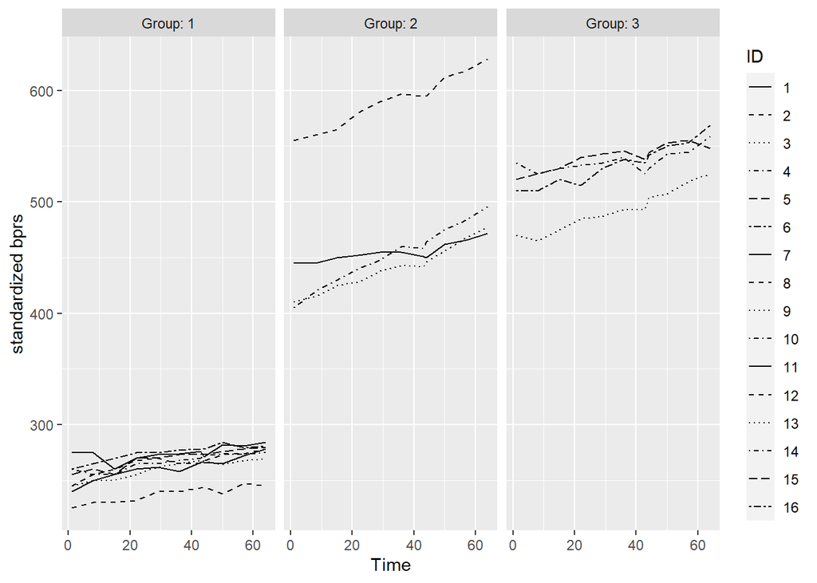

```r
library(ggplot2)

# Plot the RATSL data
ggplot(RATSL, aes(x = Time, y = Weight, linetype = ID)) +
  geom_line() +
  scale_linetype_manual(values = rep(1:10, times=4)) +
  facet_grid(. ~ Group, labeller = label_both) +
  scale_y_continuous(name = "standardized bprs")
```

After looking at the plots, it is evident that gropu 1 rats are lower weight than other groups. Also, group 3 rats seem heavier than rats in group 2, except for an outlier rat in group 2.

In all three groups, the rats have gained weight during the study (upward lines).

By standardizing the weight values, we may better analyze visually the weight gain pace of each group.
$$standardised(x) = \frac{x - mean(x)}{ sd(x)}$$

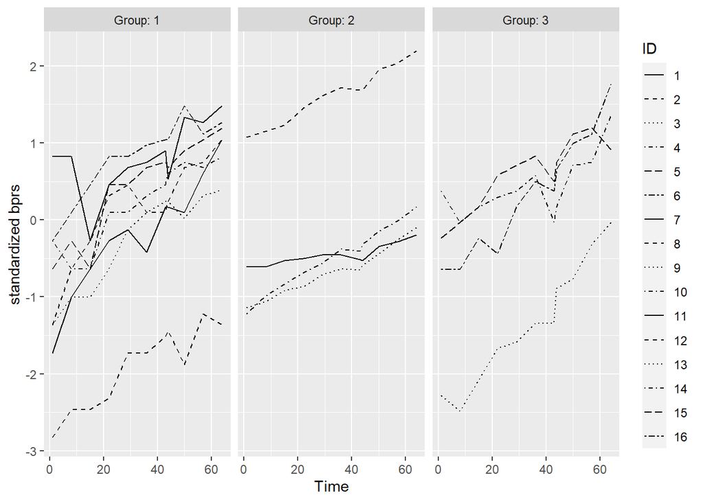

```r
# standardise RATSL data
RATSL <- RATSL %>%
  group_by(Group) %>%
  mutate(Weight_std = (Weight - mean(Weight))/sd(Weight)) %>%
  ungroup()

# plot standardized weights
ggplot(RATSL, aes(x = Time, y = Weight_std, linetype = ID)) +
  geom_line() +
  scale_linetype_manual(values = rep(1:10, times=4)) +
  facet_grid(. ~ Group, labeller = label_both) +
  scale_y_continuous(name = "standardized bprs")
```

```r
# Summary data with mean and standard error of bprs by treatment and week
RATSLS <- RATSL %>%
  group_by(Group, Time) %>%
  summarise( mean = mean(Weight), se = sd(Weight)  ) %>%
  ungroup()
# Glimpse the data
glimpse(RATSLS)
```

```
## Rows: 33
## Columns: 4
## $ Group <fct> 1, 1, 1, 1, 1, 1, 1, 1, 1, 1, 1, 2, 2, 2, 2, 2, 2, 2, 2, 2, 2, 2~
## $ Time  <int> 1, 8, 15, 22, 29, 36, 43, 44, 50, 57, 64, 1, 8, 15, 22, 29, 36, ~
## $ mean  <dbl> 250.625, 255.000, 254.375, 261.875, 264.625, 265.000, 267.375, 2~
## $ se    <dbl> 15.22158, 13.09307, 11.47591, 13.60081, 11.05748, 11.78377, 10.9~
```

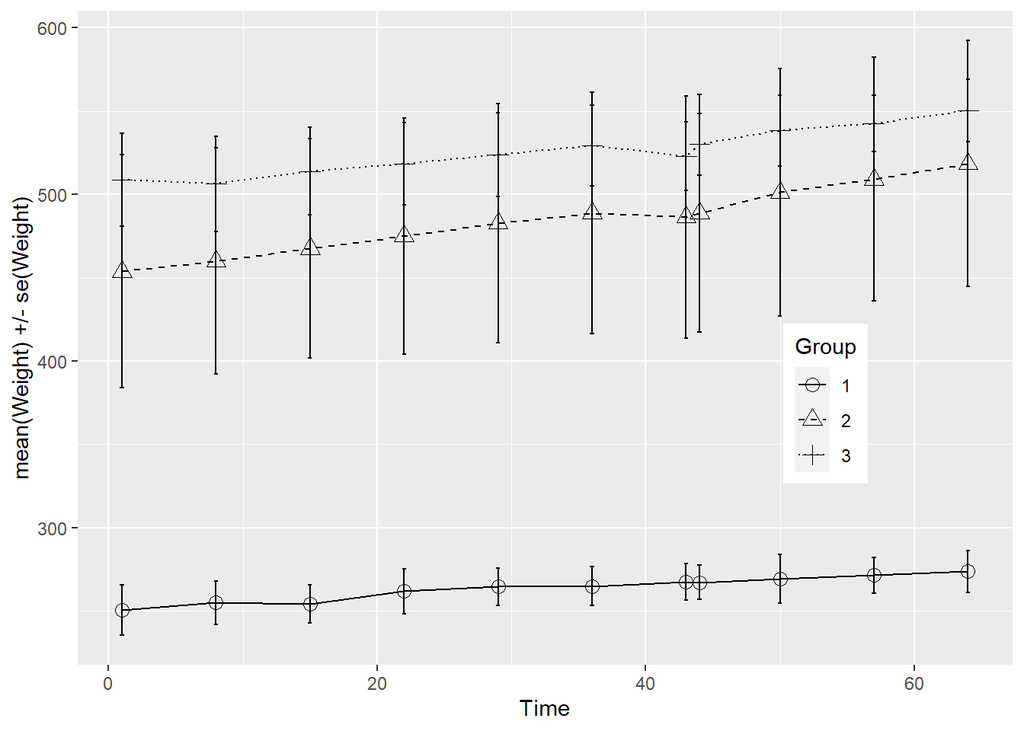

```r
# Plot the mean profiles
ggplot(RATSLS, aes(x = Time, y = mean, linetype = Group, shape = Group)) +
  geom_line() +
  scale_linetype_manual(values = c(1,2,3)) +
  geom_point(size=3) +
  scale_shape_manual(values = c(1,2,3)) +
  geom_errorbar(aes(ymin=mean - se, ymax= mean + se, linetype="1"), width=0.3) +
  theme(legend.position = c(0.8,0.4)) +
  scale_y_continuous(name = "mean(Weight) +/- se(Weight)")
```

Group 3 is on average the heaviest. Also, it seems slightly that group 2 has the fastest weight gain on average.

```r
RATSL2 <- RATSL %>%
#  filter(Time > 0) %>%
  group_by(Group, ID) %>%
  summarise( mean=mean(Weight) ) %>%
  ungroup()
# Glimpse the data
glimpse(RATSL2)
```

```
## Rows: 16
## Columns: 3
## $ Group <fct> 1, 1, 1, 1, 1, 1, 1, 1, 2, 2, 2, 2, 3, 3, 3, 3
## $ ID    <fct> 1, 2, 3, 4, 5, 6, 7, 8, 9, 10, 11, 12, 13, 14, 15, 16
## $ mean  <dbl> 261.0909, 237.6364, 260.1818, 266.5455, 269.4545, 274.7273, 274.~
```

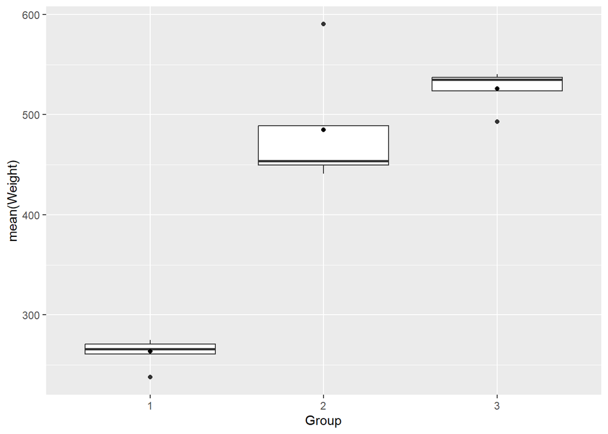

```r
# Draw a boxplot of the mean versus treatment
ggplot(RATSL2, aes(x = Group, y = mean)) +
  geom_boxplot() +
  stat_summary(fun = "mean", geom = "point", fill = "white") +
  scale_y_continuous(name = "mean(Weight)")
```

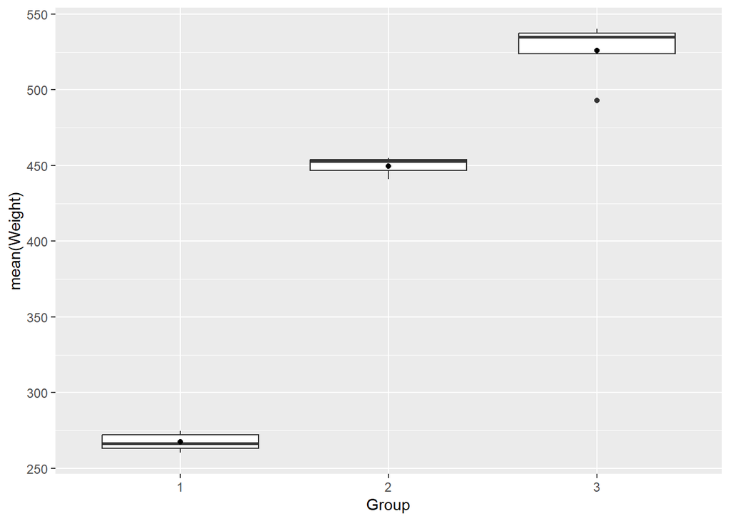

```r
# Remove outliers
RATSL21 <- RATSL2 %>%
  filter(mean < 550 & mean > 240 )

ggplot(RATSL21, aes(x = Group, y = mean)) +
  geom_boxplot() +
  stat_summary(fun = "mean", geom = "point", fill = "white") +
  scale_y_continuous(name = "mean(Weight)")
```

```r
min(RATSL21$mean)
```

```
## [1] 260.1818
```

It seems that outlier especially in group 2 has an affect on the results.

```r
# Perform a two-sample t-test
# Make group lists
groups <- list()
for(i in 1:3) groups[[i]] <- RATSL21$mean[which(RATSL21$Group == i)]

# 1 vs. 2
t.test(groups[[1]], groups[[2]])
```

```
##
##  Welch Two Sample t-test
##
## data:  groups[[1]] and groups[[2]]
## t = -37.206, df = 3.1002, p-value = 3.259e-05
## alternative hypothesis: true difference in means is not equal to 0
## 95 percent confidence interval:
##  -197.3009 -166.7251
## sample estimates:
## mean of x mean of y
##  267.4416  449.4545
```

```r
# 1 vs. 3
t.test(groups[[1]], groups[[3]])
```

```
##
##  Welch Two Sample t-test
##
## data:  groups[[1]] and groups[[3]]
## t = -22.943, df = 3.2445, p-value = 0.0001058
## alternative hypothesis: true difference in means is not equal to 0
## 95 percent confidence interval:
##  -292.7105 -223.9973
## sample estimates:
## mean of x mean of y
##  267.4416  525.7955
```

```r
# 2 vs. 3
t.test(groups[[2]], groups[[3]])
```

```
##
##  Welch Two Sample t-test
##
## data:  groups[[2]] and groups[[3]]
## t = -6.4314, df = 3.8677, p-value = 0.003371
## alternative hypothesis: true difference in means is not equal to 0
## 95 percent confidence interval:
##  -109.74659  -42.93523
## sample estimates:
## mean of x mean of y
##  449.4545  525.7955
```

As notified earlier, there are clear differences between groups mean weights. Additionally, t-test reveals that the differences are statistically significant.

## BPRS DATA

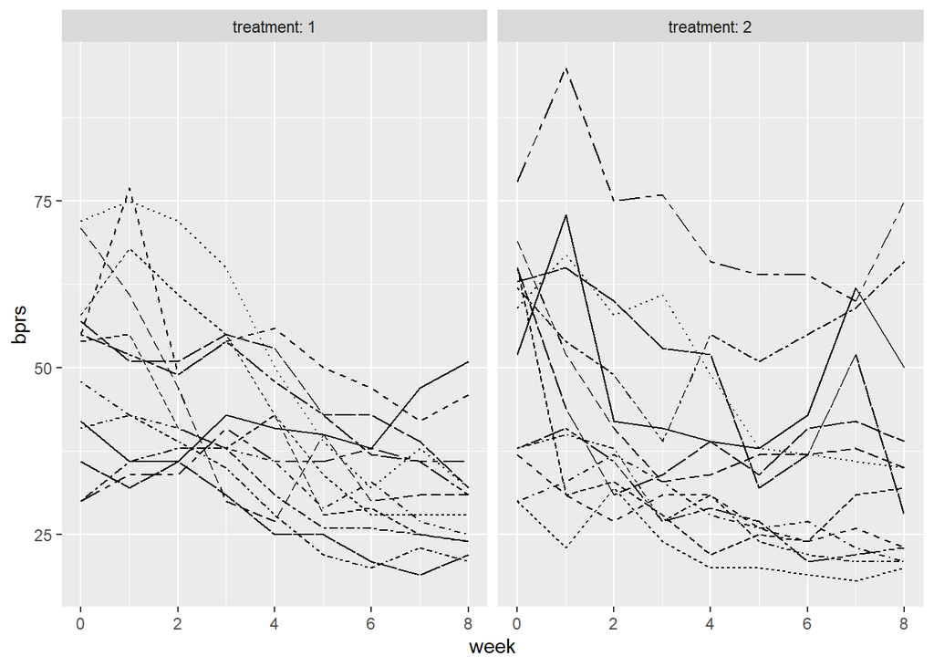

```r
# Load data

BPRSL <- read.csv("BPRSL.csv")

# Factor treatment & subject
BPRSL$treatment <- factor(BPRSL$treatment)
BPRSL$subject <- factor(BPRSL$subject)
# Convert to long form
# BPRSL <-  pivot_longer(BPRS, cols = -c(treatment, subject),
#                       names_to = "weeks", values_to = "bprs") %>%
#  arrange(weeks)

# Extract the week number
BPRSL <-  BPRSL %>%
  mutate(week = as.integer(substr(weeks, 5, 5)))

# Plot data
ggplot(BPRSL, aes(x = week, y = bprs, linetype = subject)) +
  geom_line() +
  facet_grid(. ~ treatment, labeller = label_both) +
  theme(legend.position = "none")
```

In both treatment groups there seems to me a general decreasing trend in BPRS. Subjects in the first group however seem more identical because there is less variance between subjects.

```r
# Create linear regression model
BPRS_reg <- lm(bprs ~ week + treatment, data=BPRSL)

summary(BPRS_reg)
```

```
##
## Call:
## lm(formula = bprs ~ week + treatment, data = BPRSL)
##
## Residuals:
##     Min      1Q  Median      3Q     Max
## -22.454  -8.965  -3.196   7.002  50.244
##
## Coefficients:
##             Estimate Std. Error t value Pr(>|t|)
## (Intercept)  46.4539     1.3670  33.982   <2e-16 ***
## week         -2.2704     0.2524  -8.995   <2e-16 ***
## treatment2    0.5722     1.3034   0.439    0.661
## ---
## Signif. codes:  0 '***' 0.001 '**' 0.01 '*' 0.05 '.' 0.1 ' ' 1
##
## Residual standard error: 12.37 on 357 degrees of freedom
## Multiple R-squared:  0.1851, Adjusted R-squared:  0.1806
## F-statistic: 40.55 on 2 and 357 DF,  p-value: < 2.2e-16
```

The regression model results show that there is a statistically significant relationship with variable week (expressing duration) and BPRS. Moreover, the decrease by week is on average ~2.3 points. However, no statistical significance between treatments.

```r
library(lme4)
str(BPRSL)
```

```
## 'data.frame':    360 obs. of  5 variables:
##  $ treatment: Factor w/ 2 levels "1","2": 1 1 1 1 1 1 1 1 1 1 ...
##  $ subject  : Factor w/ 20 levels "1","2","3","4",..: 1 2 3 4 5 6 7 8 9 10 ...
##  $ weeks    : chr  "week0" "week0" "week0" "week0" ...
##  $ bprs     : int  42 58 54 55 72 48 71 30 41 57 ...
##  $ week     : int  0 0 0 0 0 0 0 0 0 0 ...
```

```r
BPRS_lme <- lmer(bprs ~ week + treatment + (1 | subject), data = BPRSL, REML = FALSE)
summary(BPRS_lme)
```

```
## Linear mixed model fit by maximum likelihood  ['lmerMod']
## Formula: bprs ~ week + treatment + (1 | subject)
##    Data: BPRSL
##
##      AIC      BIC   logLik deviance df.resid
##   2748.7   2768.1  -1369.4   2738.7      355
##
## Scaled residuals:
##     Min      1Q  Median      3Q     Max
## -3.0481 -0.6749 -0.1361  0.4813  3.4855
##
## Random effects:
##  Groups   Name        Variance Std.Dev.
##  subject  (Intercept)  47.41    6.885
##  Residual             104.21   10.208
## Number of obs: 360, groups:  subject, 20
##
## Fixed effects:
##             Estimate Std. Error t value
## (Intercept)  46.4539     1.9090  24.334
## week         -2.2704     0.2084 -10.896
## treatment2    0.5722     1.0761   0.532
##
## Correlation of Fixed Effects:
##            (Intr) week
## week       -0.437
## treatment2 -0.282  0.000
```

```r
# create a random intercept and random slope model

BPRS_lme2 <- lmer(bprs ~ week + treatment + (week | subject), data = BPRSL, REML = FALSE)
summary(BPRS_lme2)
```

```
## Linear mixed model fit by maximum likelihood  ['lmerMod']
## Formula: bprs ~ week + treatment + (week | subject)
##    Data: BPRSL
##
##      AIC      BIC   logLik deviance df.resid
##   2745.4   2772.6  -1365.7   2731.4      353
##
## Scaled residuals:
##     Min      1Q  Median      3Q     Max
## -2.8919 -0.6194 -0.0691  0.5531  3.7976
##
## Random effects:
##  Groups   Name        Variance Std.Dev. Corr
##  subject  (Intercept) 64.8222  8.0512
##           week         0.9609  0.9802   -0.51
##  Residual             97.4305  9.8707
## Number of obs: 360, groups:  subject, 20
##
## Fixed effects:
##             Estimate Std. Error t value
## (Intercept)  46.4539     2.1052  22.066
## week         -2.2704     0.2977  -7.626
## treatment2    0.5722     1.0405   0.550
##
## Correlation of Fixed Effects:
##            (Intr) week
## week       -0.582
## treatment2 -0.247  0.000
```

```r
anova(BPRS_lme, BPRS_lme2)
```

```
## Data: BPRSL
## Models:
## BPRS_lme: bprs ~ week + treatment + (1 | subject)
## BPRS_lme2: bprs ~ week + treatment + (week | subject)
##           npar    AIC    BIC  logLik deviance  Chisq Df Pr(>Chisq)
## BPRS_lme     5 2748.7 2768.1 -1369.4   2738.7
## BPRS_lme2    7 2745.4 2772.6 -1365.7   2731.4 7.2721  2    0.02636 *
## ---
## Signif. codes:  0 '***' 0.001 '**' 0.01 '*' 0.05 '.' 0.1 ' ' 1
```

```r
# Create a random intercept and slope model for a group × time interaction.
BPRS_lme3 <- lmer(bprs ~ week + treatment + (week | subject) + week * treatment, data = BPRSL, REML = FALSE)
summary(BPRS_lme3)
```

```
## Linear mixed model fit by maximum likelihood  ['lmerMod']
## Formula: bprs ~ week + treatment + (week | subject) + week * treatment
##    Data: BPRSL
##
##      AIC      BIC   logLik deviance df.resid
##   2744.3   2775.4  -1364.1   2728.3      352
##
## Scaled residuals:
##     Min      1Q  Median      3Q     Max
## -3.0512 -0.6271 -0.0768  0.5288  3.9260
##
## Random effects:
##  Groups   Name        Variance Std.Dev. Corr
##  subject  (Intercept) 64.9964  8.0620
##           week         0.9687  0.9842   -0.51
##  Residual             96.4707  9.8220
## Number of obs: 360, groups:  subject, 20
##
## Fixed effects:
##                 Estimate Std. Error t value
## (Intercept)      47.8856     2.2521  21.262
## week             -2.6283     0.3589  -7.323
## treatment2       -2.2911     1.9090  -1.200
## week:treatment2   0.7158     0.4010   1.785
##
## Correlation of Fixed Effects:
##             (Intr) week   trtmn2
## week        -0.650
## treatment2  -0.424  0.469
## wek:trtmnt2  0.356 -0.559 -0.840
```

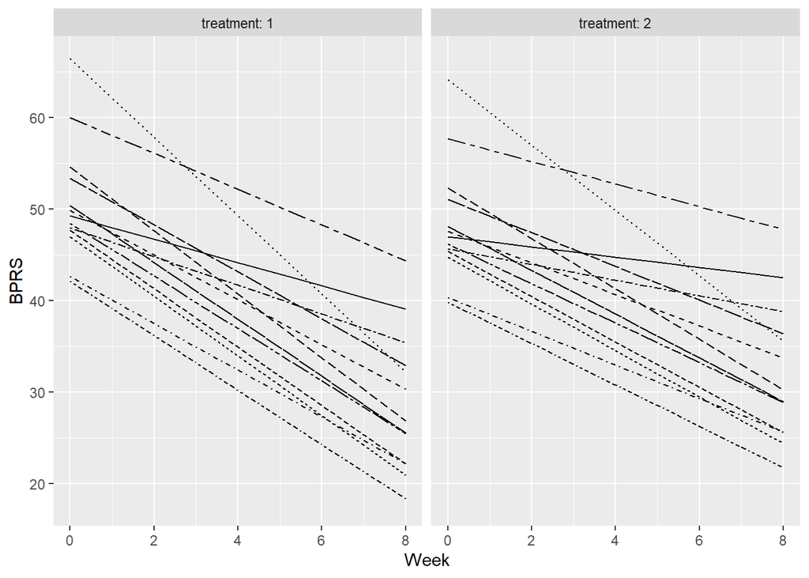

```r
# Create data with fitted valus

BPRSL_fit <- BPRSL
BPRSL_fit$bprs <- predict(BPRS_lme3)


ggplot(BPRSL_fit) +
  geom_line(aes(x = week, y = bprs, linetype = subject)) +
  scale_x_continuous(name = "Week") +
  scale_y_continuous(name = "BPRS") +
  theme(legend.position = "top") +
  facet_grid(. ~treatment, labeller=label_both) +
  theme(legend.position = "none")
```

Above is the plotted fitted model for both treatments.